# Assignment 3 - Price Estimation of Diamonds

Abdullah Yıldız

9/13/2020

# 1 Diamonds:

According to the [this site](http://www.diamondc.com.hk/us/factors-affect-diamond-price), there are many factors affecting the price of diamonds. Colour, Clarity, Carat (size), Cut, Shape and Fluorescence are the major determinants of the price of diamonds. Difference in single grade or level will make the price change from 5% to 30%.

Again from [this site](http://www.diamondc.com.hk/us/how-to-select-diamond), with many diamonds to select from, knowledge on diamond is necessary. However, it may be a novel experience for many people, in this section it is provided some useful information that will help to make the best decision from various choices.

To learn about diamond selection, there is one major rule to follow – “the 4Cs’”. They are Colour, Cut, Clarity and Carat. These characteristics, you can shop for a diamond within your budget.

I add many packages that may be useful to use in this analysis. But,I may not use some of them in that project.

# 2 Diamonds Price Estimation

That assignment aims to find a prediction model for estimating the price of a diamond given its properties.  
`rDiamonds` data set in `rggplot2` package is used for the assignment.

Training and test data sets are created.

```r
set.seed(503)
diamonds_test <- diamonds %>% mutate(diamond_id = row_number()) %>%
    group_by(cut, color, clarity) %>% sample_frac(0.2) %>% ungroup()
diamonds_train <- anti_join(diamonds %>% mutate(diamond_id = row_number()),
    diamonds_test, by = "diamond_id")
diamonds_show <- bind_rows(diamonds_train,diamonds_test)
```

Below you can see samples from train dataand test data sets.

```r
head(diamonds_train)%>%
  kbl(caption = "Sample from Training Data") %>%
  kable_minimal(full_width = F)
```

Sample from Training Data

| carat | cut | color | clarity | depth | table | price | x | y | z | diamond_id |
| --- | --- | --- | --- | --- | --- | --- | --- | --- | --- | --- |
| 0.21 | Premium | E | SI1 | 59.8 | 61 | 326 | 3.89 | 3.84 | 2.31 | 2 |
| 0.23 | Good | E | VS1 | 56.9 | 65 | 327 | 4.05 | 4.07 | 2.31 | 3 |
| 0.29 | Premium | I | VS2 | 62.4 | 58 | 334 | 4.20 | 4.23 | 2.63 | 4 |
| 0.31 | Good | J | SI2 | 63.3 | 58 | 335 | 4.34 | 4.35 | 2.75 | 5 |
| 0.24 | Very Good | I | VVS1 | 62.3 | 57 | 336 | 3.95 | 3.98 | 2.47 | 7 |
| 0.26 | Very Good | H | SI1 | 61.9 | 55 | 337 | 4.07 | 4.11 | 2.53 | 8 |

```r
head(diamonds_test)%>%
  kbl(caption = "Sample from Test Data") %>%
  kable_minimal(full_width = F)
```

Sample from Test Data

| carat | cut | color | clarity | depth | table | price | x | y | z | diamond_id |
| --- | --- | --- | --- | --- | --- | --- | --- | --- | --- | --- |
| 1.70 | Fair | D | I1 | 64.7 | 56 | 5617 | 7.46 | 7.37 | 4.80 | 13776 |
| 0.58 | Fair | D | SI2 | 65.1 | 58 | 1156 | 5.25 | 5.22 | 3.41 | 40690 |
| 1.00 | Fair | D | SI2 | 65.6 | 66 | 3767 | 6.10 | 6.01 | 3.97 | 5152 |
| 1.05 | Fair | D | SI2 | 65.4 | 59 | 3816 | 6.30 | 6.24 | 4.10 | 5359 |
| 0.70 | Fair | D | SI2 | 64.5 | 60 | 2167 | 5.53 | 5.47 | 3.55 | 49828 |
| 0.90 | Fair | D | SI2 | 64.6 | 59 | 3847 | 6.04 | 6.01 | 3.89 | 5510 |

## 2.1 Data Information

In this project as you can see above table,there are some facts which can be used to do estimation. My main goal is to provide to create understandable explatory data analysis and create model for diamond price estimation.

```r
diamonds %>%
  glimpse
```

```
## Rows: 53,940
## Columns: 10
## $ carat   <dbl> 0.23, 0.21, 0.23, 0.29, 0.31, 0.24, 0.24, 0.26, 0.22, 0.23,...
## $ cut     <ord> Ideal, Premium, Good, Premium, Good, Very Good, Very Good, ...
## $ color   <ord> E, E, E, I, J, J, I, H, E, H, J, J, F, J, E, E, I, J, J, J,...
## $ clarity <ord> SI2, SI1, VS1, VS2, SI2, VVS2, VVS1, SI1, VS2, VS1, SI1, VS...
## $ depth   <dbl> 61.5, 59.8, 56.9, 62.4, 63.3, 62.8, 62.3, 61.9, 65.1, 59.4,...
## $ table   <dbl> 55, 61, 65, 58, 58, 57, 57, 55, 61, 61, 55, 56, 61, 54, 62,...
## $ price   <int> 326, 326, 327, 334, 335, 336, 336, 337, 337, 338, 339, 340,...
## $ x       <dbl> 3.95, 3.89, 4.05, 4.20, 4.34, 3.94, 3.95, 4.07, 3.87, 4.00,...
## $ y       <dbl> 3.98, 3.84, 4.07, 4.23, 4.35, 3.96, 3.98, 4.11, 3.78, 4.05,...
## $ z       <dbl> 2.43, 2.31, 2.31, 2.63, 2.75, 2.48, 2.47, 2.53, 2.49, 2.39,...
```

```r
sum(any(is.na(diamonds)))
```

```
## [1] 0
```

There is 0 NA values.

Since there is any missing value in any row or column, we can get into next step : It should be checked whether there is a duplicated row or not.

```r
sum(as.numeric(duplicated(diamonds)))
```

```
## [1] 146
```

There are 146 duplicated lines. It should be extracted these values from dataframe.

```r
diamonds <- unique(diamonds)

sum(as.numeric(duplicated(diamonds)))
```

```
## [1] 0
```

Now, we have 53794 rows and 10 columns.Lets examine our dataset detailly such as looking data.

```r
str(diamonds)
```

```
## tibble [53,794 x 10] (S3: tbl_df/tbl/data.frame)
##  $ carat  : num [1:53794] 0.23 0.21 0.23 0.29 0.31 0.24 0.24 0.26 0.22 0.23 ...
##  $ cut    : Ord.factor w/ 5 levels "Fair"<"Good"<..: 5 4 2 4 2 3 3 3 1 3 ...
##  $ color  : Ord.factor w/ 7 levels "D"<"E"<"F"<"G"<..: 2 2 2 6 7 7 6 5 2 5 ...
##  $ clarity: Ord.factor w/ 8 levels "I1"<"SI2"<"SI1"<..: 2 3 5 4 2 6 7 3 4 5 ...
##  $ depth  : num [1:53794] 61.5 59.8 56.9 62.4 63.3 62.8 62.3 61.9 65.1 59.4 ...
##  $ table  : num [1:53794] 55 61 65 58 58 57 57 55 61 61 ...
##  $ price  : int [1:53794] 326 326 327 334 335 336 336 337 337 338 ...
##  $ x      : num [1:53794] 3.95 3.89 4.05 4.2 4.34 3.94 3.95 4.07 3.87 4 ...
##  $ y      : num [1:53794] 3.98 3.84 4.07 4.23 4.35 3.96 3.98 4.11 3.78 4.05 ...
##  $ z      : num [1:53794] 2.43 2.31 2.31 2.63 2.75 2.48 2.47 2.53 2.49 2.39 ...
```

As i search on the Internet, colorless diamonds has higher prices too, so that color levels should be sorted again. You can fin related information in [there] (https://www.petragems.com/education/diamond-color/)

```r
diamonds$color <- factor(diamonds$color, levels = c("J", "I", "H", "G", "F", "E", "D"))
```

Let’s look at the data again to be sure.

```r
str(diamonds)
```

```
## tibble [53,794 x 10] (S3: tbl_df/tbl/data.frame)
##  $ carat  : num [1:53794] 0.23 0.21 0.23 0.29 0.31 0.24 0.24 0.26 0.22 0.23 ...
##  $ cut    : Ord.factor w/ 5 levels "Fair"<"Good"<..: 5 4 2 4 2 3 3 3 1 3 ...
##  $ color  : Ord.factor w/ 7 levels "J"<"I"<"H"<"G"<..: 6 6 6 2 1 1 2 3 6 3 ...
##  $ clarity: Ord.factor w/ 8 levels "I1"<"SI2"<"SI1"<..: 2 3 5 4 2 6 7 3 4 5 ...
##  $ depth  : num [1:53794] 61.5 59.8 56.9 62.4 63.3 62.8 62.3 61.9 65.1 59.4 ...
##  $ table  : num [1:53794] 55 61 65 58 58 57 57 55 61 61 ...
##  $ price  : int [1:53794] 326 326 327 334 335 336 336 337 337 338 ...
##  $ x      : num [1:53794] 3.95 3.89 4.05 4.2 4.34 3.94 3.95 4.07 3.87 4 ...
##  $ y      : num [1:53794] 3.98 3.84 4.07 4.23 4.35 3.96 3.98 4.11 3.78 4.05 ...
##  $ z      : num [1:53794] 2.43 2.31 2.31 2.63 2.75 2.48 2.47 2.53 2.49 2.39 ...
```

```r
summary(diamonds)
```

```
##      carat               cut        color        clarity          depth
##  Min.   :0.2000   Fair     : 1598   J: 2802   SI1    :13032   Min.   :43.00
##  1st Qu.:0.4000   Good     : 4891   I: 5407   VS2    :12229   1st Qu.:61.00
##  Median :0.7000   Very Good:12069   H: 8272   SI2    : 9150   Median :61.80
##  Mean   :0.7978   Premium  :13748   G:11262   VS1    : 8156   Mean   :61.75
##  3rd Qu.:1.0400   Ideal    :21488   F: 9520   VVS2   : 5056   3rd Qu.:62.50
##  Max.   :5.0100                     E: 9776   VVS1   : 3647   Max.   :79.00
##                                     D: 6755   (Other): 2524
##      table           price             x                y
##  Min.   :43.00   Min.   :  326   Min.   : 0.000   Min.   : 0.000
##  1st Qu.:56.00   1st Qu.:  951   1st Qu.: 4.710   1st Qu.: 4.720
##  Median :57.00   Median : 2401   Median : 5.700   Median : 5.710
##  Mean   :57.46   Mean   : 3933   Mean   : 5.731   Mean   : 5.735
##  3rd Qu.:59.00   3rd Qu.: 5327   3rd Qu.: 6.540   3rd Qu.: 6.540
##  Max.   :95.00   Max.   :18823   Max.   :10.740   Max.   :58.900
##
##        z
##  Min.   : 0.000
##  1st Qu.: 2.910
##  Median : 3.530
##  Mean   : 3.539
##  3rd Qu.: 4.030
##  Max.   :31.800
##
```

```r
head(diamonds)
```

```
## # A tibble: 6 x 10
##   carat cut       color clarity depth table price     x     y     z
##   <dbl> <ord>     <ord> <ord>   <dbl> <dbl> <int> <dbl> <dbl> <dbl>
## 1 0.23  Ideal     E     SI2      61.5    55   326  3.95  3.98  2.43
## 2 0.21  Premium   E     SI1      59.8    61   326  3.89  3.84  2.31
## 3 0.23  Good      E     VS1      56.9    65   327  4.05  4.07  2.31
## 4 0.290 Premium   I     VS2      62.4    58   334  4.2   4.23  2.63
## 5 0.31  Good      J     SI2      63.3    58   335  4.34  4.35  2.75
## 6 0.24  Very Good J     VVS2     62.8    57   336  3.94  3.96  2.48
```

##Preprocessing

Now,I start to control values of some variables such as price , dimensions of diamond (x,y,z) and etc. . All they have should have logical values as I learned from operation research in detailly. I will filter these values to make my estimation and analyze more accurate in following codes.

```r
diamonds %>%
  filter(price <= 0) %>%
  summarise(NegativePrice = n())
```

```
## # A tibble: 1 x 1
##   NegativePrice
##           <int>
## 1             0
```

```r
diamonds %>%
  filter(x <= 0 & y > 0 & z > 0)
```

```
## # A tibble: 0 x 10
## # ... with 10 variables: carat <dbl>, cut <ord>, color <ord>, clarity <ord>,
## #   depth <dbl>, table <dbl>, price <int>, x <dbl>, y <dbl>, z <dbl>
```

```r
diamonds %>%
  filter(y <= 0 & z > 0 & x > 0)
```

```
## # A tibble: 0 x 10
## # ... with 10 variables: carat <dbl>, cut <ord>, color <ord>, clarity <ord>,
## #   depth <dbl>, table <dbl>, price <int>, x <dbl>, y <dbl>, z <dbl>
```

```r
diamonds %>%
  filter(z <= 0 & y > 0 & x > 0)
```

```
## # A tibble: 12 x 10
##    carat cut     color clarity depth table price     x     y     z
##    <dbl> <ord>   <ord> <ord>   <dbl> <dbl> <int> <dbl> <dbl> <dbl>
##  1  1    Premium G     SI2      59.1    59  3142  6.55  6.48     0
##  2  1.01 Premium H     I1       58.1    59  3167  6.66  6.6      0
##  3  1.1  Premium G     SI2      63      59  3696  6.5   6.47     0
##  4  1.01 Premium F     SI2      59.2    58  3837  6.5   6.47     0
##  5  1.5  Good    G     I1       64      61  4731  7.15  7.04     0
##  6  1.15 Ideal   G     VS2      59.2    56  5564  6.88  6.83     0
##  7  2.18 Premium H     SI2      59.4    61 12631  8.49  8.45     0
##  8  2.25 Premium I     SI1      61.3    58 15397  8.52  8.42     0
##  9  2.2  Premium H     SI1      61.2    59 17265  8.42  8.37     0
## 10  2.02 Premium H     VS2      62.7    53 18207  8.02  7.95     0
## 11  2.8  Good    G     SI2      63.8    58 18788  8.9   8.85     0
## 12  1.12 Premium G     I1       60.4    59  2383  6.71  6.67     0
```

```r
diamonds %>%
  filter(x <= 0 & z <= 0)
```

```
## # A tibble: 7 x 10
##   carat cut       color clarity depth table price     x     y     z
##   <dbl> <ord>     <ord> <ord>   <dbl> <dbl> <int> <dbl> <dbl> <dbl>
## 1  1.07 Ideal     F     SI2      61.6    56  4954     0  6.62     0
## 2  1    Very Good H     VS2      63.3    53  5139     0  0        0
## 3  1.14 Fair      G     VS1      57.5    67  6381     0  0        0
## 4  1.56 Ideal     G     VS2      62.2    54 12800     0  0        0
## 5  1.2  Premium   D     VVS1     62.1    59 15686     0  0        0
## 6  2.25 Premium   H     SI2      62.8    59 18034     0  0        0
## 7  0.71 Good      F     SI2      64.1    60  2130     0  0        0
```

```r
diamonds %>%
  filter(y <= 0 & z <= 0)
```

```
## # A tibble: 6 x 10
##   carat cut       color clarity depth table price     x     y     z
##   <dbl> <ord>     <ord> <ord>   <dbl> <dbl> <int> <dbl> <dbl> <dbl>
## 1  1    Very Good H     VS2      63.3    53  5139     0     0     0
## 2  1.14 Fair      G     VS1      57.5    67  6381     0     0     0
## 3  1.56 Ideal     G     VS2      62.2    54 12800     0     0     0
## 4  1.2  Premium   D     VVS1     62.1    59 15686     0     0     0
## 5  2.25 Premium   H     SI2      62.8    59 18034     0     0     0
## 6  0.71 Good      F     SI2      64.1    60  2130     0     0     0
```

```r
diamonds %>%
  filter(x <= 0 & y <= 0 )
```

```
## # A tibble: 6 x 10
##   carat cut       color clarity depth table price     x     y     z
##   <dbl> <ord>     <ord> <ord>   <dbl> <dbl> <int> <dbl> <dbl> <dbl>
## 1  1    Very Good H     VS2      63.3    53  5139     0     0     0
## 2  1.14 Fair      G     VS1      57.5    67  6381     0     0     0
## 3  1.56 Ideal     G     VS2      62.2    54 12800     0     0     0
## 4  1.2  Premium   D     VVS1     62.1    59 15686     0     0     0
## 5  2.25 Premium   H     SI2      62.8    59 18034     0     0     0
## 6  0.71 Good      F     SI2      64.1    60  2130     0     0     0
```

```r
diamonds = diamonds %>%
  filter(!(x == 0 & z == 0))
diamonds %>%
  filter(x == 0 | y == 0 | z == 0)
```

```
## # A tibble: 12 x 10
##    carat cut     color clarity depth table price     x     y     z
##    <dbl> <ord>   <ord> <ord>   <dbl> <dbl> <int> <dbl> <dbl> <dbl>
##  1  1    Premium G     SI2      59.1    59  3142  6.55  6.48     0
##  2  1.01 Premium H     I1       58.1    59  3167  6.66  6.6      0
##  3  1.1  Premium G     SI2      63      59  3696  6.5   6.47     0
##  4  1.01 Premium F     SI2      59.2    58  3837  6.5   6.47     0
##  5  1.5  Good    G     I1       64      61  4731  7.15  7.04     0
##  6  1.15 Ideal   G     VS2      59.2    56  5564  6.88  6.83     0
##  7  2.18 Premium H     SI2      59.4    61 12631  8.49  8.45     0
##  8  2.25 Premium I     SI1      61.3    58 15397  8.52  8.42     0
##  9  2.2  Premium H     SI1      61.2    59 17265  8.42  8.37     0
## 10  2.02 Premium H     VS2      62.7    53 18207  8.02  7.95     0
## 11  2.8  Good    G     SI2      63.8    58 18788  8.9   8.85     0
## 12  1.12 Premium G     I1       60.4    59  2383  6.71  6.67     0
```

As It can be seen , still there are some Z values “0”. After thinking how i can find z values just konwing x, y values, I thought to look at dataset again and see the superhero : “Depth”. It’s time to calculate Z from x,y and depth.

```r
diamonds = diamonds %>%
  mutate(z = ifelse(z == 0 & x != 0 & y != 0,round(depth * mean(c(x, y)) / 100, 2), z))
```

Controlling dataframe again

```r
diamonds = diamonds %>%
  filter(!(x == 0 & z == 0))
diamonds %>%
  filter(x == 0 | y == 0 | z == 0)
```

```
## # A tibble: 0 x 10
## # ... with 10 variables: carat <dbl>, cut <ord>, color <ord>, clarity <ord>,
## #   depth <dbl>, table <dbl>, price <int>, x <dbl>, y <dbl>, z <dbl>
```

Yeah! there are any row has zero value.

Now, we can compare the x, y and z values with each other. These values should be highly correlated with each other.

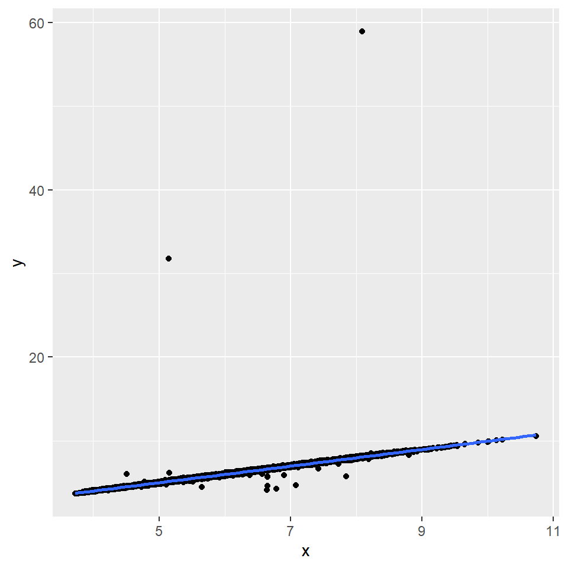

```r
diamonds %>%
  ggplot(., aes(x = x, y = y)) +
  geom_point() +
  geom_smooth(method = "lm")
```

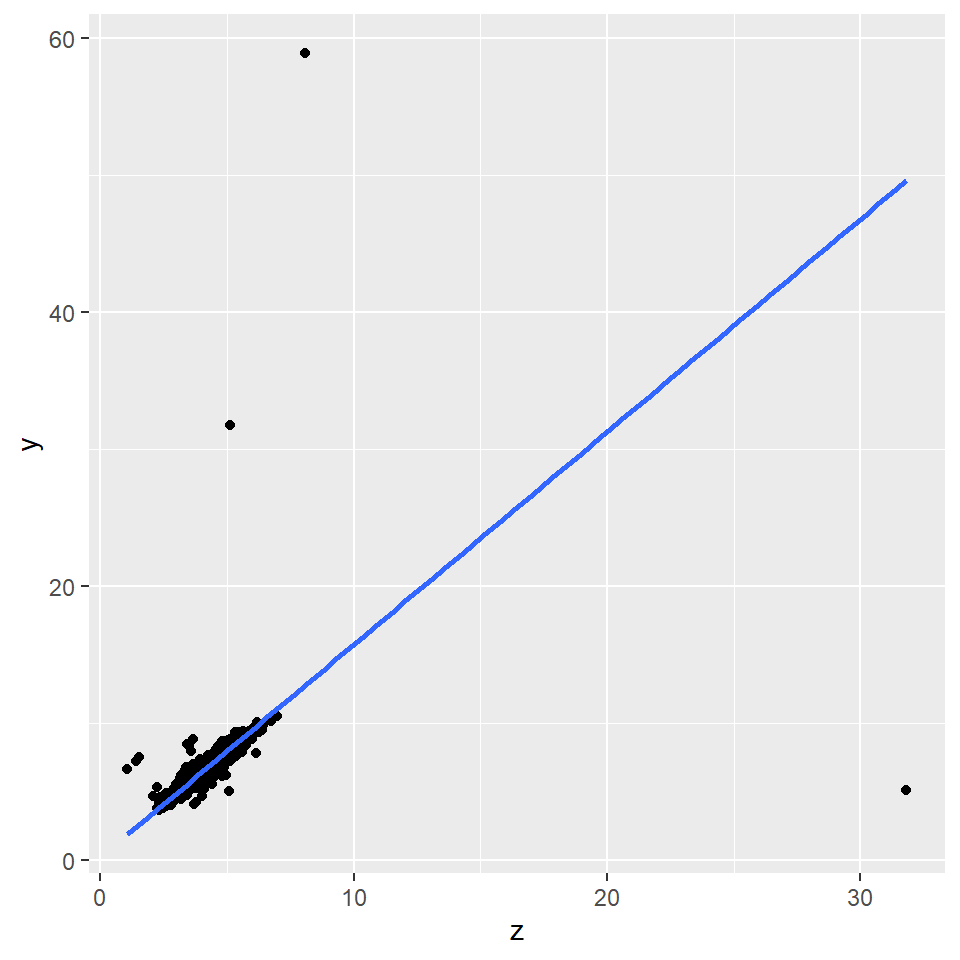

```r
diamonds %>%
  ggplot(., aes(x = z, y = y)) +
  geom_point() +
  geom_smooth(method = "lm")
```

As it showed almost all these values are highly correlated except some outliers. I prefer to ignore them because I think these outliers would not affect my analysis in sight.

# 3 EDA: Explatory Data Analysis

As I mentioned above there are 4 criterias that affects the price and quality of diamonds. Now its time to examine each of the 4Cs’ :

*Colour, Cut, Clarity and Carat.*

## 3.1 The Relation Between Carat, Depth, Table, Cut with Price

- The relation between price and other variables are visualized below.

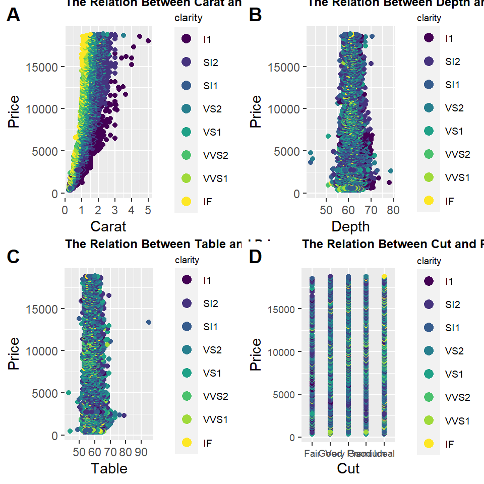

```r
plotone<-ggplot(diamonds, aes(x=carat, y=price, color=clarity)) + geom_point()+labs(x="Carat", y="Price",title="The Relation Between Carat and Price")+theme(plot.title = element_text(size=9,face="bold",vjust=5),legend.title = element_text(size = 8),legend.text = element_text(size = 7)) +
        guides(shape = guide_legend(override.aes = list(size = 1.25)),
               color = guide_legend(override.aes = list(size =3)))
plottwo<-ggplot(diamonds, aes(x=depth, y=price, color=clarity)) + geom_point()+labs(x="Depth", y="Price",title="The Relation Between Depth and Price")+theme(plot.title = element_text(size=9,face="bold",vjust=5),legend.title = element_text(size = 7),legend.text = element_text(size = 7))+
        guides(shape = guide_legend(override.aes = list(size = 1.25)),
               color = guide_legend(override.aes = list(size =3)))
plotthree<-ggplot(diamonds, aes(x=table, y=price, color=clarity)) + geom_point()+labs(x="Table", y="Price",title="The Relation Between Table and Price")+theme(plot.title = element_text(size=9,face="bold",vjust=5),legend.title = element_text(size = 7),legend.text = element_text(size = 7))+
        guides(shape = guide_legend(override.aes = list(size = 1.25)),
               color = guide_legend(override.aes = list(size =3)))
plotfour<-ggplot(diamonds, aes(x=cut, y=price, color=clarity)) + geom_point()+labs(x="Cut", y="Price",title="The Relation Between Cut and Price")+theme(plot.title = element_text(size=9,face="bold",vjust=5),legend.title = element_text(size = 7),legend.text = element_text(size = 7),axis.text=element_text(size=7))+
        guides(shape = guide_legend(override.aes = list(size = 1.25)),
               color = guide_legend(override.aes = list(size =3)))
plot_grid(plotone, plottwo,plotthree,plotfour, labels = "AUTO")
```

### 3.1.1 Colour

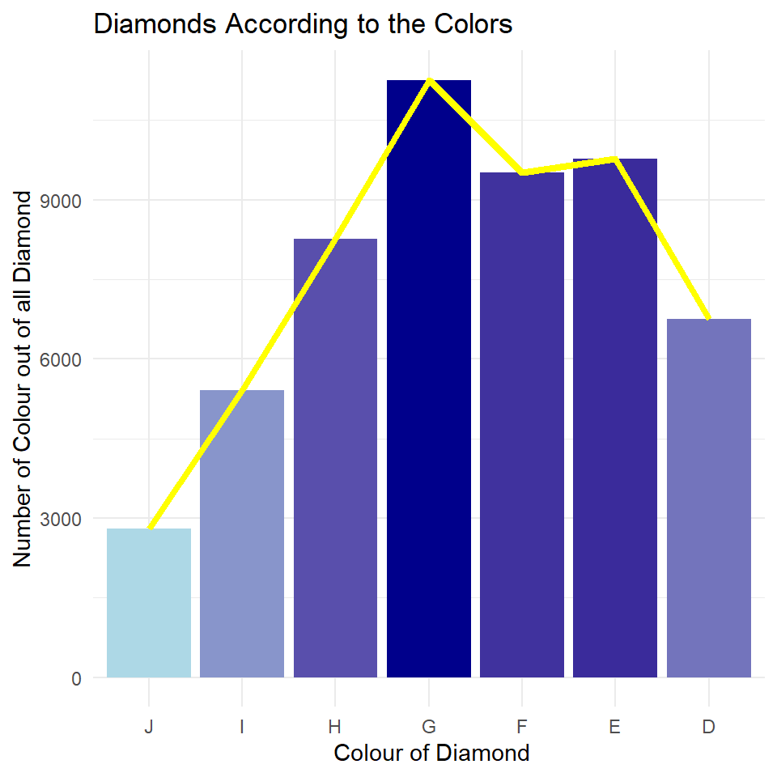

```r
diamonds %>%
  group_by(color)%>%
  summarise(count = n()) %>%
  ggplot(., aes(x=color, y = count, fill = count)) +
    geom_col() +
    scale_fill_gradient("count", low="lightblue", high="darkblue") +
    geom_line(aes(y = count), size = 1.5, color="yellow", group = 1) +
    theme_minimal() +
    theme(legend.position = "none") +
    labs(title = "Diamonds According to the Colors",
         x = " Colour of Diamond",
         y = "Number of Colour out of all Diamond")
```

Bar chart show us that the most used color in diamonds are G, while the least one is J.

```r
diamonds %>%
  group_by(color)%>%
  summarise(color_count = n(),
            MinPrice = min(price),
            MaxPrice = max(price),
            AveragePrice = mean(price))%>%
  kable(col.names = c("Color", "Count","Minimum Price",  "Maximum Price","Average Price"))
```

| Color | Count | Minimum Price | Maximum Price | Average Price |
| --- | --- | --- | --- | --- |
| J | 2802 | 335 | 18710 | 5326.415 |
| I | 5407 | 334 | 18823 | 5081.751 |
| H | 8270 | 337 | 18803 | 4481.137 |
| G | 11260 | 354 | 18818 | 4000.359 |
| F | 9518 | 342 | 18791 | 3726.788 |
| E | 9776 | 326 | 18731 | 3079.608 |
| D | 6754 | 357 | 18693 | 3172.589 |

### 3.1.2 Cut

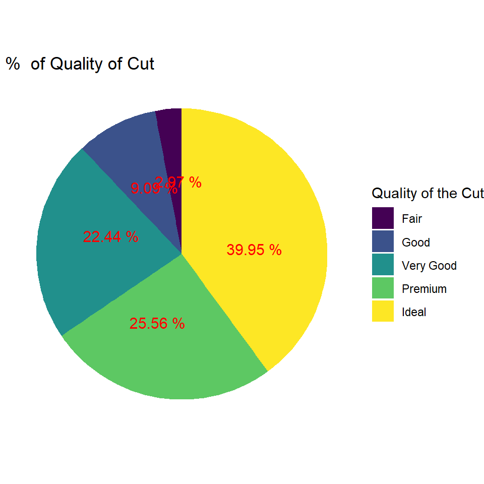

```r
diamonds %>%
  group_by(cut) %>%
  summarise(count = n()) %>%
  mutate(percentage = 100*count/sum(count)) %>%
  ggplot(., aes(x = '', y = count, fill = cut)) +
    geom_bar(width = 2, stat = "identity", alpha = 1.3) +
    coord_polar("y") +
    theme_void() +
    theme(plot.title = element_text(vjust = 0.8)) +
    geom_text(aes(label = paste(format(percentage,digits=3), "%")), size=4, color = "red", position = position_stack(vjust = 0.6)) +
    labs(title = " %  of Quality of Cut ",
         fill = "Quality of the Cut")
```

The chart above illustrates that greatest majority of cut is ideal cut. When other facts are ignored, Ideals one should be more expensive. Lets look at our max,min table again.

The surprising fact is the most expensives cuts looks like *premium and fair*

```r
diamonds %>%
  group_by(cut)%>%
  summarise(cut_count = n(),
            MinPrice = min(price),
            MaxPrice = max(price),
            AveragePrice = mean(price))%>%
  kable(col.names = c("Cut", "Count","Minimum Price",  "Maximum Price","Average Price"))
```

| Cut | Count | Minimum Price | Maximum Price | Average Price |
| --- | --- | --- | --- | --- |
| Fair | 1597 | 337 | 18574 | 4340.678 |
| Good | 4890 | 327 | 18788 | 3919.487 |
| Very Good | 12068 | 336 | 18818 | 3980.920 |
| Premium | 13746 | 326 | 18823 | 4581.716 |
| Ideal | 21486 | 326 | 18806 | 3462.246 |

### 3.1.3 Clarity

Clarity is defines how much is stain existed in diamond.

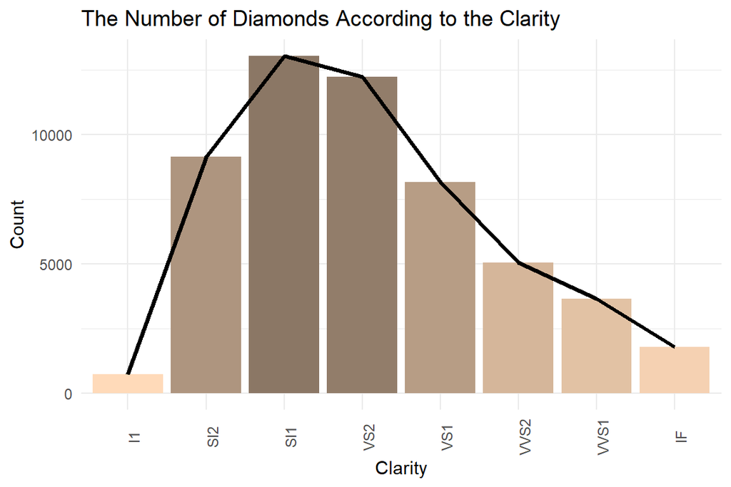

```r
diamonds %>%
  mutate(clarity = factor(clarity)) %>%
  group_by(clarity) %>%
  summarise(clarity_count = n()) %>%

  ggplot(., aes(x=clarity, y = clarity_count, fill = clarity_count)) +
  geom_col() +
  scale_fill_gradient("clarity_count", low="peachpuff", high="peachpuff4") +
  geom_line(aes(y = clarity_count), size = 1.2, color="black", group = 1) +
  theme_minimal() +
  theme(legend.position = "none") +
  theme(axis.text.x = element_text(angle = 90), legend.position = "none")+
        labs(title = "The Number of Diamonds According to the Clarity",
         x = "Clarity",
         y = "Count")
```

```r
diamonds %>%
  group_by(clarity)%>%
  summarise(clarity_count = n(),
            MinPrice = min(price),
            MaxPrice = max(price),
            AveragePrice = mean(price))%>%
  kable(col.names = c("Clarity", "Count","Minimum Price",  "Maximum Price","Average Price"))
```

| Clarity | Count | Minimum Price | Maximum Price | Average Price |
| --- | --- | --- | --- | --- |
| I1 | 740 | 345 | 18531 | 3925.276 |
| SI2 | 9147 | 326 | 18804 | 5056.368 |
| SI1 | 13032 | 326 | 18818 | 3996.165 |
| VS2 | 12227 | 334 | 18823 | 3926.917 |
| VS1 | 8155 | 327 | 18795 | 3841.300 |
| VVS2 | 5056 | 336 | 18768 | 3286.532 |
| VVS1 | 3646 | 336 | 18777 | 2522.994 |
| IF | 1784 | 369 | 18806 | 2870.570 |

### 3.1.4 Carat

A carat is a unit of measurement used to specify the weight of a diamond. ‘Carat’ is a diamond industry special word for the weight of a diamond stone. One carat is equal to 200 milligrams, for example, a 5-carat stone will weigh 1 gram.

People often mistakenly assume that a diamond’s size is synonymous with its carat weight, though that’s not necessarily true. Like a human body the more the weight, the more likely the size is bigger, but other factors also affect the size. The way in which the diamond is cut will greatly affect the diameter and brilliance of the diamond. Diamonds with a poorer cut (for example, a change of depth or a thick girdle) will maintain their heavy weight but ‘hidden’ in the base of the diamond with less surface on top so they look smaller.

[figure not shown]

```r
diamonds %>%
  mutate(carat = factor(carat)) %>%
  group_by(carat) %>%
  summarise(carat_count = n())%>%
  arrange(desc(carat_count)) %>%
  head(5) %>%
  ggplot(., aes(y=carat_count, x = reorder(carat,-carat_count), fill = carat)) +
  geom_col() +
  geom_text(aes(label = carat_count), size=3, color = "black", position = position_stack(vjust = 0.60)) +
  theme_minimal() +
  scale_fill_brewer(palette = c("Paired")) +
  theme(legend.position = "none") +
  labs(title = "The Most 10 Popular Carat",
       x = "Carat", y = "Count")
```

According to the data set, the most preferable carat is 0.3 carat. In table above it seems 0.3-0.31-0.32 are some of the most existed carats.To see all of them, I also create a table you can see below. By lookig at table, it can be also seen the price effect to carats.

```r
diamonds %>%
  group_by(carat) %>%
  summarise(carat_count = n(),
            MinPrice = min(price),
            MaxPrice = max(price),
            AveragePrice = mean(price))%>%
  arrange(desc(AveragePrice)) %>%
  kable(col.names = c("Carat", "Number of Carats","Minimum Price", "Maximum Price", "Average Price")) %>%
  kable_minimal (full_width = T)
```

| Carat | Number of Carats | Minimum Price | Maximum Price | Average Price |
| --- | --- | --- | --- | --- |
| 3.51 | 1 | 18701 | 18701 | 18701.0000 |
| 2.67 | 1 | 18686 | 18686 | 18686.0000 |
| 4.50 | 1 | 18531 | 18531 | 18531.0000 |
| 5.01 | 1 | 18018 | 18018 | 18018.0000 |
| 2.57 | 3 | 17116 | 18485 | 17841.6667 |
| 2.60 | 3 | 17027 | 18369 | 17535.0000 |
| 2.64 | 1 | 17407 | 17407 | 17407.0000 |
| 2.66 | 2 | 16239 | 18495 | 17367.0000 |
| 4.13 | 1 | 17329 | 17329 | 17329.0000 |
| 2.39 | 7 | 15917 | 17955 | 17182.4286 |
| 2.71 | 1 | 17146 | 17146 | 17146.0000 |
| 3.04 | 2 | 15354 | 18559 | 16956.5000 |
| 2.42 | 7 | 16198 | 18615 | 16923.5714 |
| 2.80 | 2 | 15030 | 18788 | 16909.0000 |
| 1.93 | 6 | 13278 | 18306 | 16828.1667 |
| 2.56 | 3 | 15231 | 17753 | 16723.3333 |
| 2.51 | 17 | 14209 | 18308 | 16616.8824 |
| 2.61 | 3 | 13784 | 18756 | 16583.0000 |
| 2.53 | 8 | 14659 | 18254 | 16548.8750 |
| 2.48 | 9 | 12883 | 18692 | 16537.1111 |
| 2.37 | 6 | 14837 | 18508 | 16525.1667 |
| 2.59 | 1 | 16465 | 16465 | 16465.0000 |
| 2.44 | 4 | 13027 | 18430 | 16365.5000 |
| 2.40 | 13 | 11988 | 18541 | 16362.4615 |
| 2.65 | 1 | 16314 | 16314 | 16314.0000 |
| 2.52 | 9 | 10076 | 18252 | 16242.1111 |
| 3.67 | 1 | 16193 | 16193 | 16193.0000 |
| 2.35 | 7 | 14185 | 17999 | 16090.4286 |
| 2.32 | 16 | 6860 | 18532 | 16042.1875 |
| 4.00 | 1 | 15984 | 15984 | 15984.0000 |

[output cut: 243 more lines]

# 4 Create Model

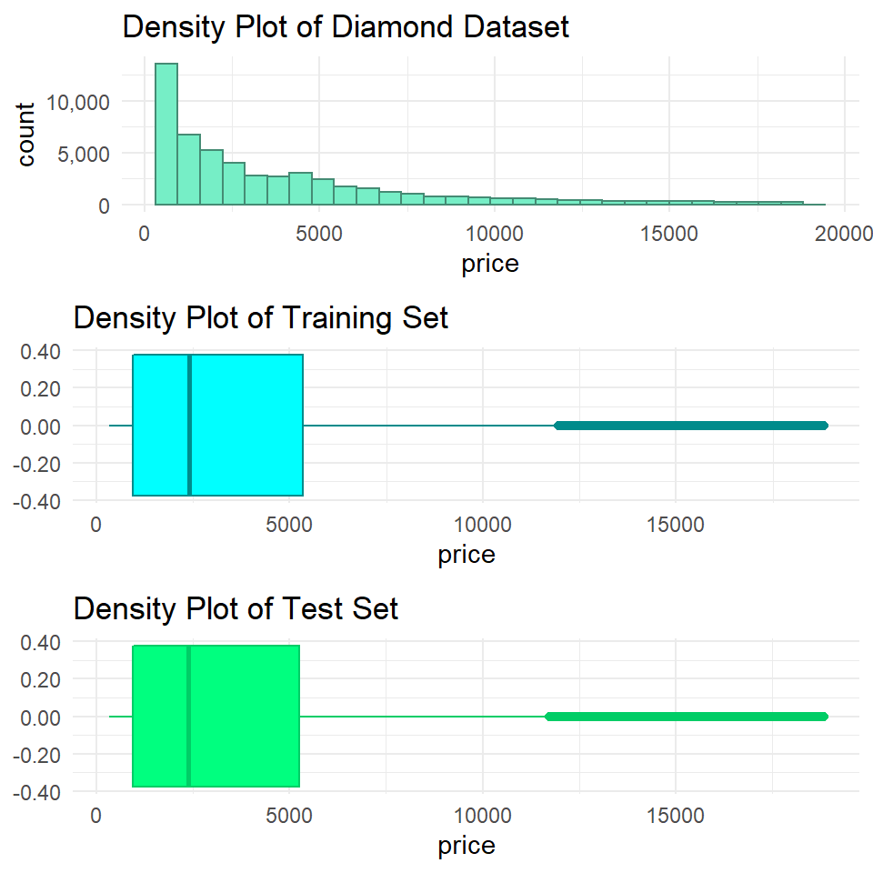

```r
alldata <- ggplot(diamonds, aes(x=price))+
  geom_histogram  (color="aquamarine4", fill="aquamarine2")+ggtitle("Density Plot of Diamond Dataset")+theme_minimal()+ scale_y_continuous(labels = comma)
traindata <- ggplot(diamonds_train, aes(x=price))+
  geom_boxplot (color="cyan4", fill="cyan1")+ ggtitle("Density Plot of Training Set")+
  theme_minimal()+ scale_y_continuous(labels = comma)
testdata <- ggplot(diamonds_test, aes(x=price))+geom_boxplot(color="springgreen3", fill="springgreen1")+ggtitle("Density Plot of Test Set")+
  theme_minimal()+scale_y_continuous(labels = comma)
ggarrange(alldata, traindata, testdata, ncol = 1, nrow = 3)
```

```r
Main_model <- glm(price~x+y+z+carat,family = Gamma,data=diamonds_train,start=c(0.5,0.5,0.5,0.5,0.5))
summary(Main_model)
```

```
##
## Call:
## glm(formula = price ~ x + y + z + carat, family = Gamma, data = diamonds_train,
##     start = c(0.5, 0.5, 0.5, 0.5, 0.5))
##
## Deviance Residuals:
##     Min       1Q   Median       3Q      Max
##  -1.609   27.789   37.925   47.602  185.614
##
## Coefficients:
##              Estimate Std. Error t value Pr(>|t|)
## (Intercept)  0.997131   6.301847   0.158    0.874
## x           -0.123070   0.677494  -0.182    0.856
## y           -0.001192   0.079861  -0.015    0.988
## z           -0.012507   1.163875  -0.011    0.991
## carat        0.084792   1.134872   0.075    0.940
##
## (Dispersion parameter for Gamma family taken to be 929969)
##
##     Null deviance:    42391  on 43142  degrees of freedom
## Residual deviance: 71665391  on 43138  degrees of freedom
## AIC: 1355333
##
## Number of Fisher Scoring iterations: 25
```

As you can see , significance of Z is the least. Thus, I create a new model without Z and expect an improvement in AIC score.

```r
Second_Model <- glm(price~x+y+carat,family = Gamma,
        data=diamonds_train,
        start=c(0.5,0.5,0.5,0.5))
summary(Second_Model)
```

```
##
## Call:
## glm(formula = price ~ x + y + carat, family = Gamma, data = diamonds_train,
##     start = c(0.5, 0.5, 0.5, 0.5))
##
## Deviance Residuals:
##    Min      1Q  Median      3Q     Max
## -2.459   6.701   9.499  12.187  47.485
##
## Coefficients:
##               Estimate Std. Error t value Pr(>|t|)
## (Intercept)  0.0661368  0.0217451   3.041  0.00236 **
## x           -0.0084667  0.0027822  -3.043  0.00234 **
## y           -0.0001106  0.0003123  -0.354  0.72312
## carat        0.0052078  0.0017105   3.045  0.00233 **
## ---
## Signif. codes:  0 '***' 0.001 '**' 0.01 '*' 0.05 '.' 0.1 ' ' 1
##
## (Dispersion parameter for Gamma family taken to be 17.1283)
##
##     Null deviance:   42391  on 43142  degrees of freedom
## Residual deviance: 4605070  on 43139  degrees of freedom
## AIC: 1122205
##
## Number of Fisher Scoring iterations: 25
```

In third all variables affect price significantly with a significance level of 0.05.

```r
Third_Model <- glm(price~x+carat,family = Gamma,
        data=diamonds_train,
        start=c(0.5,0.5,0.5))
summary(Third_Model)
```

```
##
## Call:
## glm(formula = price ~ x + carat, family = Gamma, data = diamonds_train,
##     start = c(0.5, 0.5, 0.5))
##
## Deviance Residuals:
##     Min       1Q   Median       3Q      Max
## -3.5868  -0.7725  -0.2709   0.1667   5.5165
##
## Coefficients:
##               Estimate Std. Error t value Pr(>|t|)
## (Intercept)  1.088e-03  2.971e-06   366.2   <2e-16 ***
## x           -1.493e-04  4.145e-07  -360.2   <2e-16 ***
## carat        1.118e-04  3.752e-07   297.9   <2e-16 ***
## ---
## Signif. codes:  0 '***' 0.001 '**' 0.01 '*' 0.05 '.' 0.1 ' ' 1
##
## (Dispersion parameter for Gamma family taken to be 0.5907617)
##
##     Null deviance: 42391  on 43142  degrees of freedom
## Residual deviance: 17671  on 43140  degrees of freedom
## AIC: 758803
##
## Number of Fisher Scoring iterations: 25
```

## 4.1 Generalized Linear Model (GLM)

Here is my final model :

```r
Final_Model <- glm(price~x+carat,family = Gamma(link="identity"),
                  data=diamonds_train,
                  start=c(0.5,0.5,0.5))
summary(Final_Model)
```

```
##
## Call:
## glm(formula = price ~ x + carat, family = Gamma(link = "identity"),
##     data = diamonds_train, start = c(0.5, 0.5, 0.5))
##
## Deviance Residuals:
##      Min        1Q    Median        3Q       Max
## -1.11278  -0.24172  -0.06862   0.15353   1.94617
##
## Coefficients:
##             Estimate Std. Error t value Pr(>|t|)
## (Intercept) -944.147      7.698 -122.65   <2e-16 ***
## x            -41.138      1.431  -28.75   <2e-16 ***
## carat       5934.790     14.336  413.98   <2e-16 ***
## ---
## Signif. codes:  0 '***' 0.001 '**' 0.01 '*' 0.05 '.' 0.1 ' ' 1
##
## (Dispersion parameter for Gamma family taken to be 0.1116708)
##
##     Null deviance: 42390.6  on 43142  degrees of freedom
## Residual deviance:  4431.9  on 43140  degrees of freedom
## AIC: 696940
##
## Number of Fisher Scoring iterations: 25
```

### 4.1.1 Residual Plot

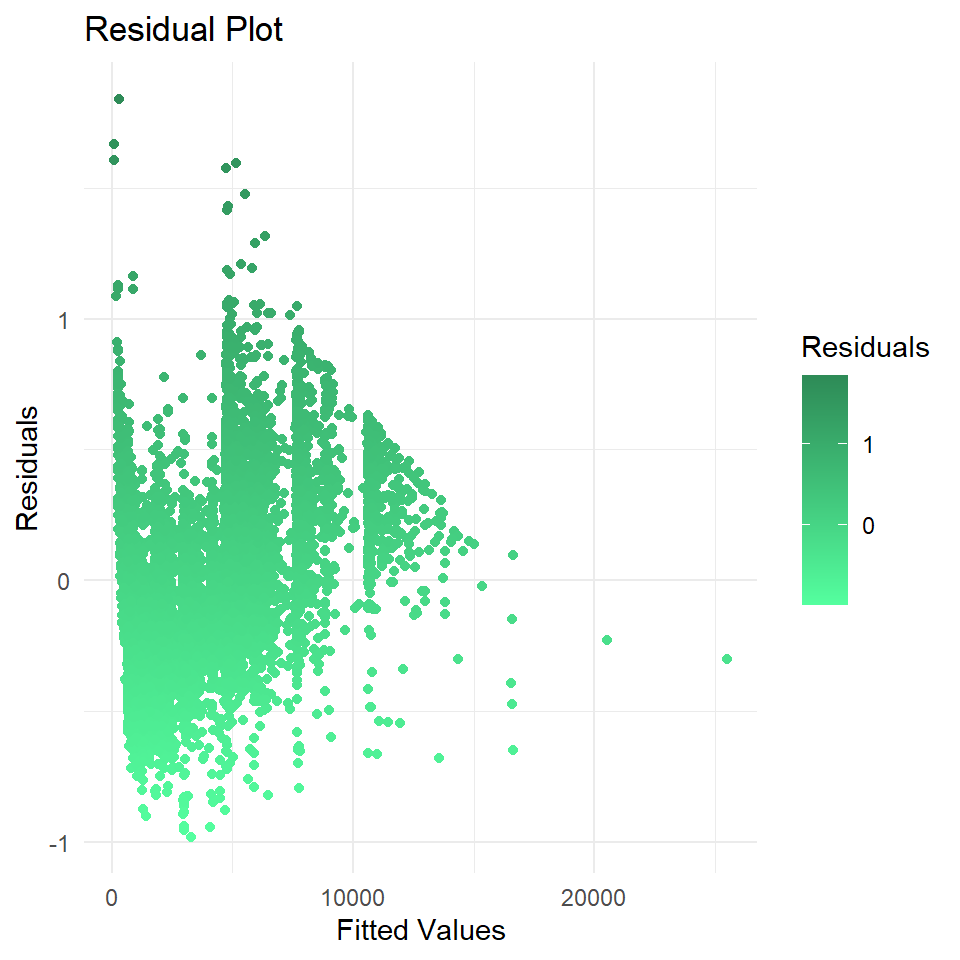

```r
Final_Model_Test_Data <- glm(price~x+carat,family = Gamma(link="identity"),
                  data=diamonds_test,
                  start=c(0.5,0.5,0.5))
ggplot(Final_Model_Test_Data) +
  geom_point(aes(x=.fitted, y=.resid, col=.resid)) +
  theme_minimal() +
  ggtitle("Residual Plot") +
  labs(x = "Fitted Values",
       y = "Residuals") +
  scale_color_gradient(low="seagreen1", high="seagreen4") +
  labs(col = "Residuals")
```

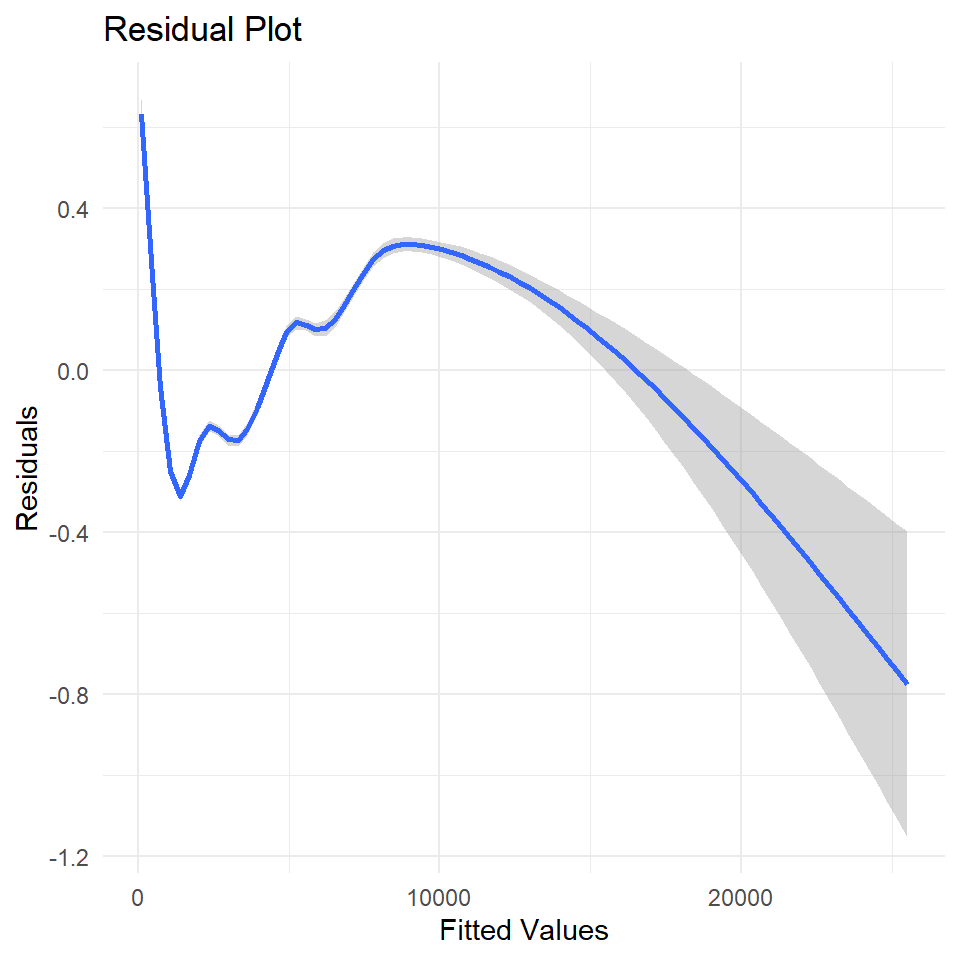

```r
Final_Model_Test_Data <- glm(price~x+carat,family = Gamma(link="identity"),
                  data=diamonds_test,
                  start=c(0.5,0.5,0.5))
ggplot(Final_Model_Test_Data) +
  geom_smooth (aes(x=.fitted, y=.resid, col=.resid)) +
  theme_minimal() +
  ggtitle("Residual Plot") +
  labs(x = "Fitted Values",
       y = "Residuals") +
  scale_color_gradient(low="lemonchiffon", high="lemonchiffon4") +
  labs(col = "Residuals")
```

### 4.1.2 References

[Gamma Distribution](https://wiki.analytica.com/index.php?title=Gamma_distribution) [Diamond Exploration Price Modeling](https://www.kaggle.com/abhishekheads/diamond-exploration-price-modeling)  
[EDA Example with Diamonds data set](http://rstudio-pubs-static.s3.amazonaws.com/400929_1fe468939a9c4d9c8cf8e8768ab5fb3c.html)  
[Wikipedia](https://en.wikipedia.org/wiki/Diamond)  
[Color Cheatsheet](https://www.nceas.ucsb.edu/sites/default/files/2020-04/colorPaletteCheatsheet.pdf)  
[Diamond Guide](https://shiningdiamonds.co.uk/diamond-buying-guide/diamond-carat)  
[Geom Histogram](http://www.sthda.com/english/wiki/ggplot2-histogram-plot-quick-start-guide-r-software-and-data-visualization)  
[Ideal Cut](https://www.diamonds.pro/education/diamond-depth-and-table/#:~:text=For%20a%20cushion%20cut%20diamond,or%2069%20to%2070%20percent)